# Linkage TCA Approaches - TCA Actions

How do the concept definitions link across the TCA/Nexus key-sets?

Author

Rainer M. Krug

Published

August 25, 2026

This report examines **how the TCA/Nexus concept definitions link to one another across the two key-sets** — especially the association between **TCA Approaches and TCA Actions** — and how coherent the definition set itself is. It builds toward the **Approach × Action** heatmap at the end.

The heavier corpus-wide analyses (chapter alignment, score distributions, work-type and citation breakdowns) and the cited-literature-embedding “Stage 3” signal have been removed: they depend on the full-corpus embeddings, which are no longer computed in this pruned pipeline.

# Definition set

## Definition coherence

How tight is the definition set itself? Pairwise cosine similarity between the definitions (title_abstract variant), reordered by average-linkage hierarchical clustering. A coherent set shows clear high-similarity blocks on the diagonal.

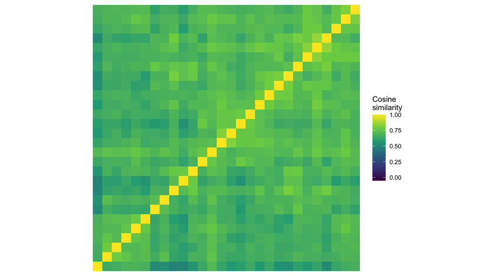

Figure 1: Pairwise cosine similarity between definitions (title_abstract variant). Axis order is from hierarchical clustering (1 − cosine, average linkage). Block structure on the diagonal indicates topical sub-groups within the definition set.

```r
tar_read(viz_keypaper_self_sim_fig)
```

```r
cat(fig_download_links_md("keypaper_self_sim"))
```

**Download:** PNG · SVG · PDF

# Keyset linkage

How do the concept definitions link *to one another* across the two key-sets (the worksheet groups `TCA_Approaches_3_2` and `TCA_Actions_Ch5`)? The association of interest is **TCA Approaches with TCA Actions**, shown below as Sankeys and heatmaps. Two complementary similarity signals drive it:

- **Stage 1 — definition-text similarity (embeddings):** cosine similarity between the concept definition embeddings (title_abstract, `BAAI/bge-large-en-v1.5`, 1024-dim; title and abstract are concatenated directly, as BGE has no `[SEP]` convention). Two definitions link if their *wording/concepts* are close.
- **Stage 2 — cited-literature overlap (no embeddings):** two definitions link if they *cite the same works* — Jaccard overlap (Jaccard 1912) of the resolved cited-work sets.

Both measures are **symmetric**: the association between an Approach and an Action carries no direction, so the Sankeys’ left-to-right arrangement is a layout convention, not a claim about influence.

Jaccard, P. (1912). The distribution of the flora in the alpine zone. *New Phytologist*, 11(2), 37–50. https://doi.org/10.1111/j.1469-8137.1912.tb05611.x (the “coefficient of community”, defined on p. 39: species common to both / total species in both).

## Keyset × keyset overview

These matrices give the whole picture: the mean similarity between *every* pair of key-sets, per signal stage (read a row against the columns). Means are taken over all ordered definition pairs in each keyset combination, zeros included.

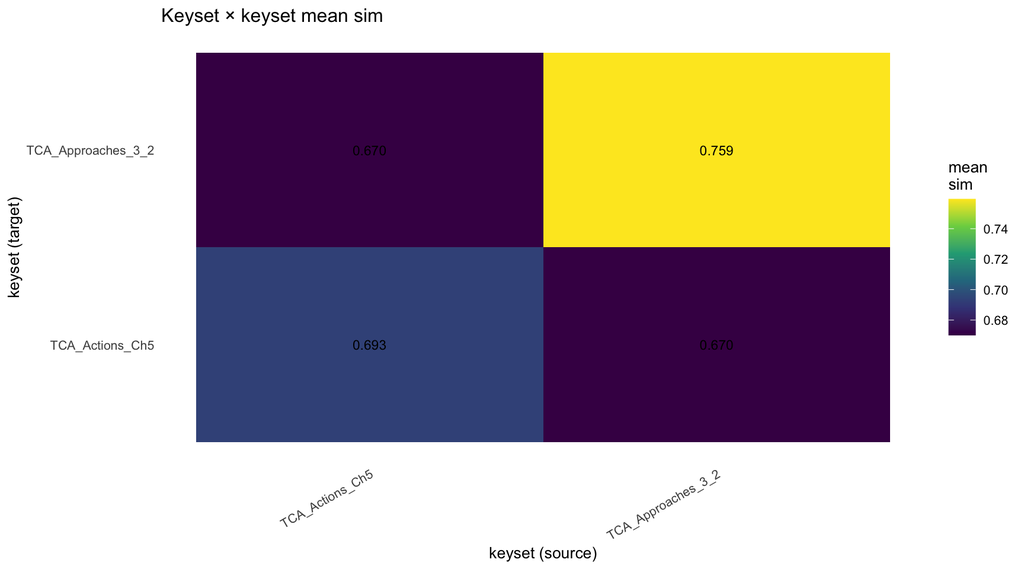

Figure 2: Stage 1 — keyset × keyset mean definition-embedding cosine similarity.

```r
tar_read(viz_keyset_matrix_stage1_fig)
```

```r
cat(fig_download_links_md("keyset_matrix_stage1"))
```

**Download:** PNG · SVG · PDF

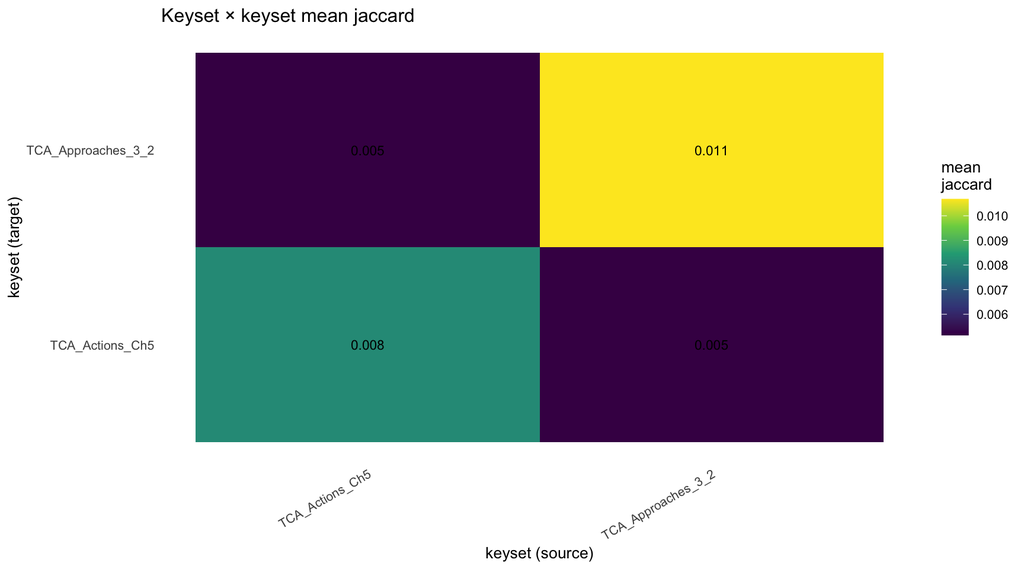

Figure 3: Stage 2 — keyset × keyset mean Jaccard overlap of cited-work sets, averaged over every ordered pair of definitions including the many that share no citations at all (so the values are small).

```r
tar_read(viz_keyset_matrix_stage2_fig)
```

```r
cat(fig_download_links_md("keyset_matrix_stage2"))
```

**Download:** PNG · SVG · PDF

## TCA Approaches ↔︎ TCA Actions Ch5

**TCA Approaches with TCA Actions**: for each Approach, its most-similar Actions under each signal stage.

The Sankeys above only show each Approach’s top matches; the heatmaps below show every Approach × Action pair for both signals. Black borders mark cells in the **top 5% of all concept-definition pairs** for that measure. This is a rank threshold, not a statistical test: about 5% of any set of pairs clears it by construction, there is no null model of “no association”, and no correction is applied for the 264 simultaneous comparisons. Treat a border as “unusually high for this measure”, not as evidence against chance.

### Stage 1 — definition-text similarity (embeddings)

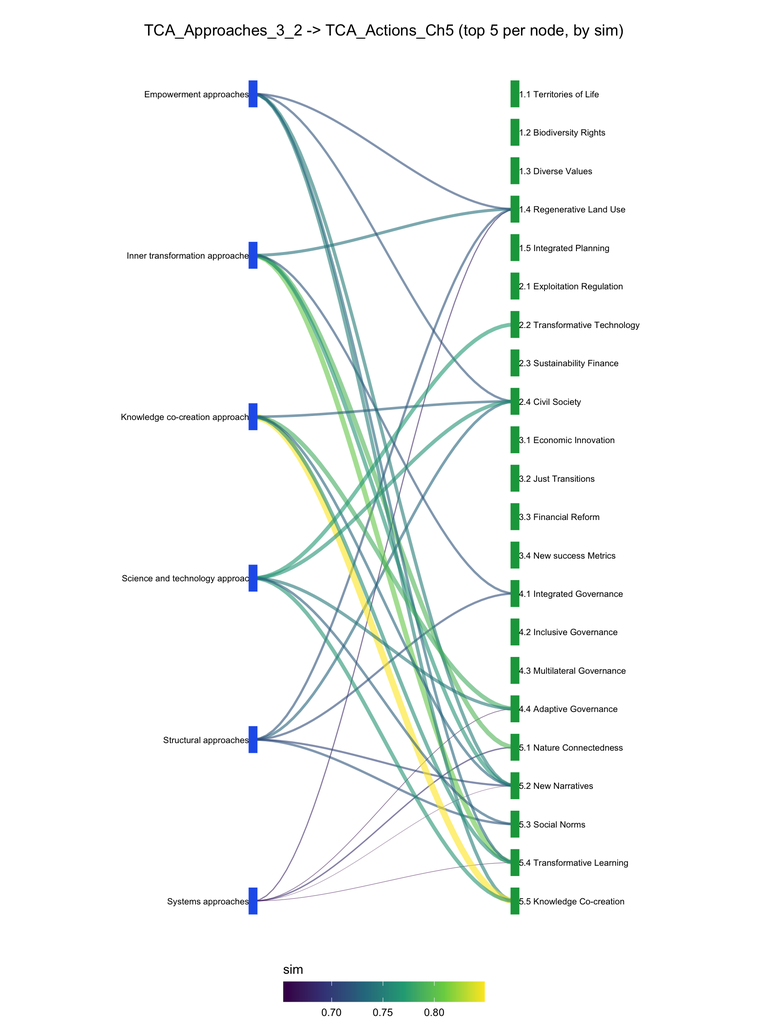

Figure 4

```r
tar_read(viz_sankey_appr_act_stage1_ggplot_fig)
```

```r
cat(fig_download_links_md("sankey_appr_act_stage1_definition_embedding_ggplot"))
```

**Download:** PNG · SVG · PDF

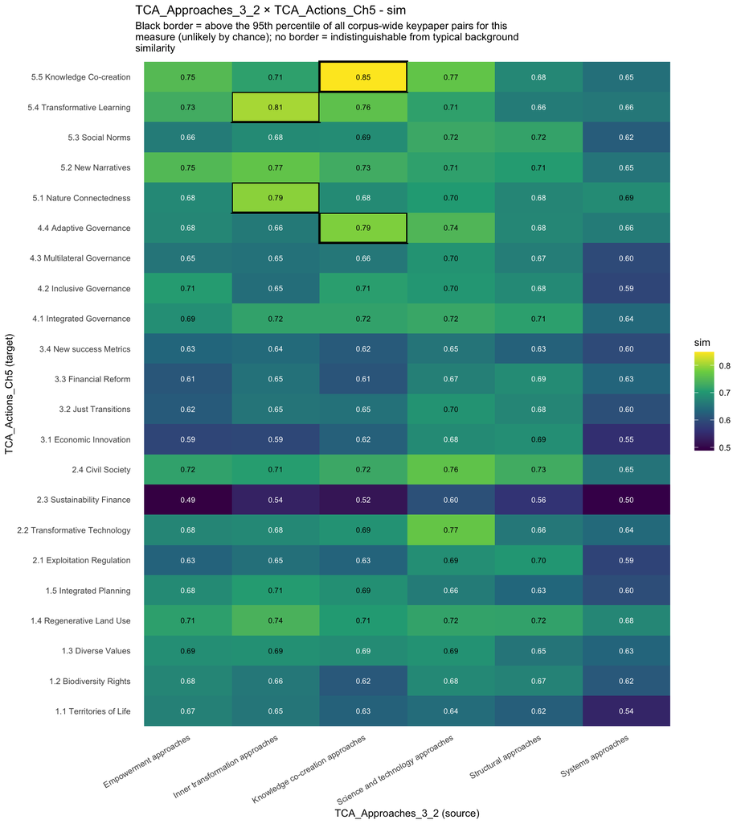

Figure 5: Approach × Action, Stage 1 (definition-text cosine similarity). Black border = in the top 5% of all ordered pairs of concept definitions on this measure.

```r
tar_read(viz_pair_heatmap_appr_act_stage1_fig)
```

```r
cat(fig_download_links_md("pair_heatmap_appr_act_stage1"))
```

**Download:** PNG · SVG · PDF

### Stage 2 — cited-literature overlap (no embeddings)

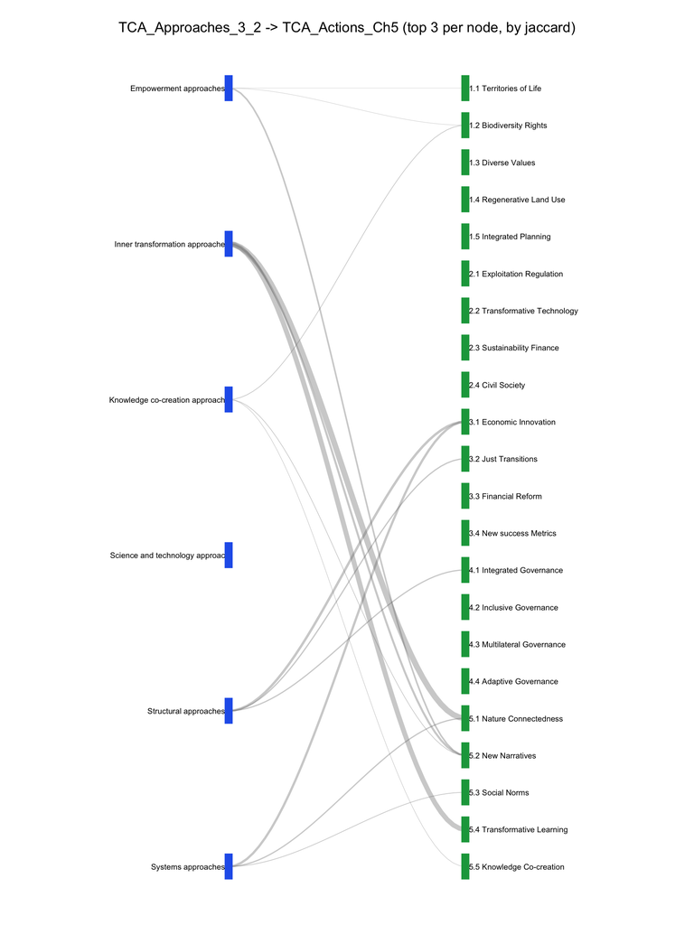

Figure 6

```r
tar_read(viz_sankey_appr_act_stage2_ggplot_fig)
```

```r
cat(fig_download_links_md("sankey_appr_act_stage2_citation_overlap_ggplot"))
```

**Download:** PNG · SVG · PDF

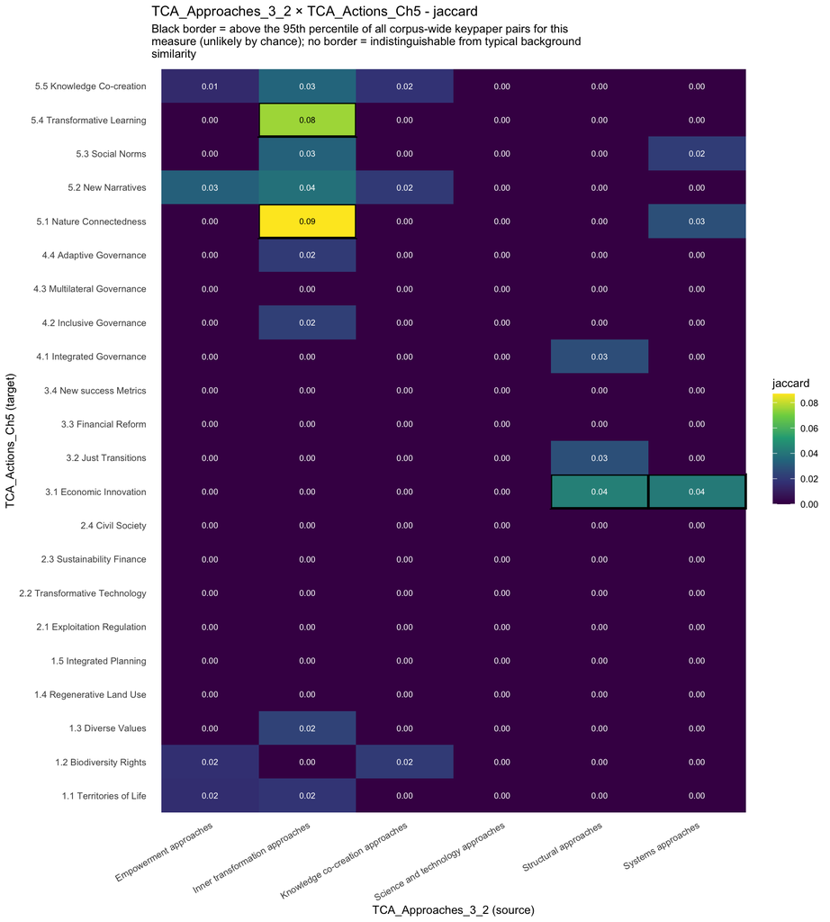

Figure 7: Approach × Action, Stage 2 (cited-literature Jaccard overlap). Black border = in the top 5% of all ordered pairs of concept definitions on this measure (the reference distribution includes the many zero-overlap pairs).

```r
tar_read(viz_pair_heatmap_appr_act_stage2_fig)
```

```r
cat(fig_download_links_md("pair_heatmap_appr_act_stage2"))
```

**Download:** PNG · SVG · PDF

### Semantic similarity, confirmed by shared citations

The colour shows **Stage 1 alone** — the semantic similarity of the two definitions, expressed as a percentile rank against that measure’s distribution over all ordered pairs of concept definitions. Stage 2 is *not* blended into it; it acts as an independent **confirmation** layer, carried by the border, the bold rule and the printed citation number.

This is deliberate. Citation overlap is very sparse — only **22 of the 132** Approach × Action pairs share any cited work at all — so averaging it into a continuous scale added almost nothing while costing a great deal. Because every one of the 110 zero-overlap pairs receives the same constant Stage-2 rank, the old blended score was an exact affine rescale of Stage 1 for those cells (correlation 1.000000); all the blending achieved was to compress them into the middle half of the colour scale, so that a semantically top-percentile pair with no shared citations could never appear more than mid-red. Showing Stage 1 directly restores the full range, and lets the citation evidence do what it is actually able to do: corroborate.

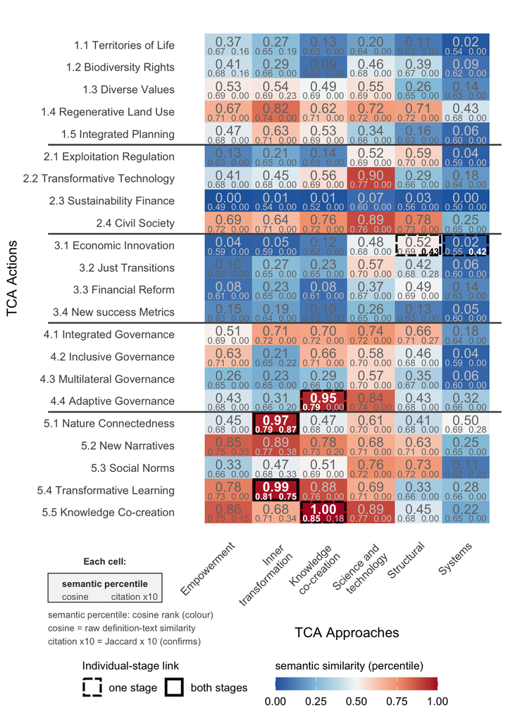

Figure 8

```r
tar_read(viz_pair_heatmap_appr_act_combined_fig)
```

```r
cat(fig_download_links_md("pair_heatmap_appr_act_combined"))
```

**Download:** PNG · SVG · PDF · EPS

*Approach × Action. **Center number** (large) = the Stage-1 semantic percentile, which is also what the **fill colour** shows; **bottom-left** (small) = the underlying raw cosine similarity; **bottom-right** (small) = Stage 2 cited-literature Jaccard overlap, **multiplied by 10** so it is legible (raw values run 0–0.09 and would print as “0.00” for most cells) — the scaling is display-only and affects neither the colour, the bold rule nor the border. **Bold** marks a value in the top 5% of all concept-definition pairs for its own measure. Border style (solid = both stages, dashed = one stage only) is keyed in the figure’s own “Individual-stage link” legend. Emphasis follows the unrounded value, so two cells printing the same rounded number can differ.

**The colour and the border answer different questions.** The fill is the Stage-1 percentile on ColorBrewer’s colour-blind-safe RdBu palette, ranked against **all ordered pairs of concept definitions, including Action–Action and Approach–Approach pairs**. Because within-keyset pairs are systematically more similar than Approach × Action pairs, the plotted cells sit lower in that reference distribution than a naive reading of “0.5 = average” would suggest; treat the colour as a ranking across the figure rather than an absolute verdict on a single pair.

The border and the bold citation number are the **confirmation**: they mark where an individual stage falls in the top 5% for its own measure. The informative combinations are a deeply red cell **with** a border — semantics and shared literature agreeing — and a pale cell **with** a dashed border, where the definitions are only moderately alike in wording but demonstrably draw on the same sources.

Three limitations to keep in mind when reading Stage 2. First, it is close to **binary rather than graded**: pairs sharing no citations all sit at the same rank (0.39), and the smallest non-zero overlap already jumps to 0.77. Second, Jaccard is **normalised by reference-list size**, so it measures proportional rather than absolute overlap — a pair sharing one reference out of few can outrank a pair sharing two out of many, and indeed does so here. Third, definitions with **longer reference lists tend to look better connected** — r = 0.42 between an Action’s citation count and its mean semantic percentile across Approaches. Note this association survives even though the colour no longer uses citations at all, so it is not purely an artefact of the Jaccard measure. The “Jaccard overlap” is Jaccard’s coefficient of community (Jaccard 1912, p. 39; species common to both / total species in both) — the term “Jaccard index” is a later name, not used in the original paper.*